# Multilevel model

Susannah Tysor

July 7, 2018

## Purpose

This document is a summary of a multilevel model of phenology.

## Data

Data is from 1999 to 2011, 3 provenances, 87 clones represented by ~2 individual ramets each located at a site in Prince George.

Data represents phenological state at the ramet level for pollen shed categorized as

- 1 Not started
- 2 Shedding pollen
- 3 Finished shedding pollen

Data is censored, especially on the front end. [Account for censoring in model using brms built in cens() function]

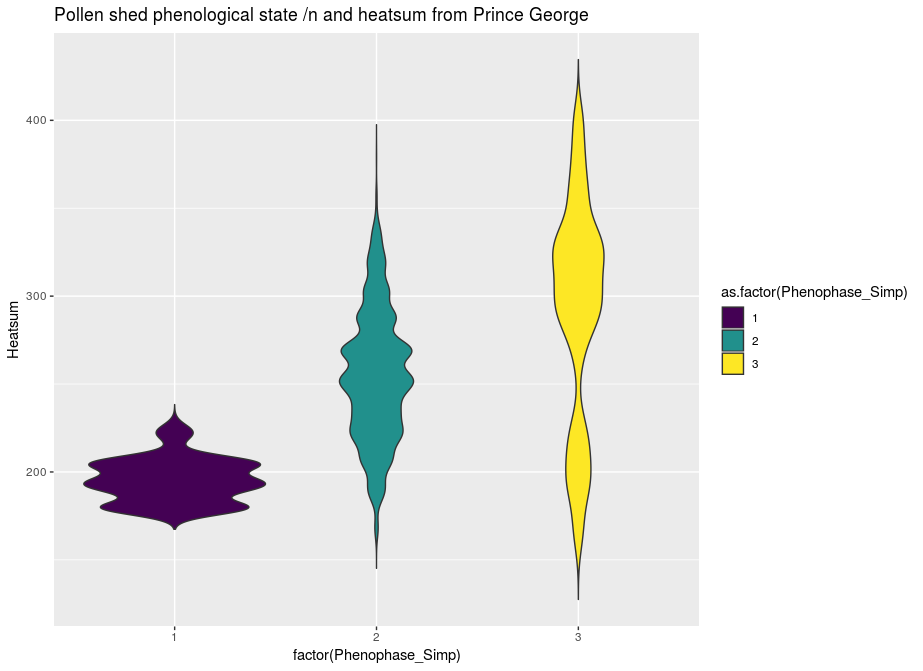

Image Caption: A violin plot of the heatsums that the three phenological states occur at.

[Add the data from Walsh with the other 6 sites.]

Heat sum data is calculated from Prince George weather station data. Heat sums are calculated beginning Jan 1. The amount of heat added assumes no heating below 5 degrees C. [Eventually try fitting this as a parameter]

## Model

The model is a multilevel ordered categorical model with a cumulative link function. So transitions between states are logistic. The response is phenological state and the explanatory variable is heat sum. Current levels are individual ramet and clones. [Add proper levels for provenance and site.]

Transition speed has a wide beta prior that constrains transition speed to reasonable values (between 0 and 1). [Translate additional priors from rethinking syntax to brms syntax, esp threshold temperature priors from Webber and Walsh irrigation experiment (2008 report)]

```r
fit3 = brm(
    bf(
        Phenophase_Simp ~
            Heatsum + (Heatsum+ 1|Tree/Clone/Orchard)),
    family = cumulative(),
    prior = set_prior("beta(2,5)", class = "b", coef="Heatsum"),
    data = df,
    chains = 5,
    cores = 5,
    refresh = 50,
    iter = 3e3,
    warmup = 1000,
    save_model = "brm.stan"
)
```

Model estimates are

```r
# summary(fit3)
# Family: cumulative
#   Links: mu = logit; disc = identity
# Formula: Phenophase_Simp ~ Heatsum + (Heatsum + 1 | Tree/Clone/Orchard)
#    Data: df (Number of observations: 2334)
# Samples: 5 chains, each with iter = 3000; warmup = 1000; thin = 1;
#          total post-warmup samples = 10000
#
# Group-Level Effects:
# ~Tree (Number of levels: 38)
#                        Estimate Est.Error l-95% CI u-95% CI Eff.Sample Rhat
# sd(Intercept)              3.27      1.01     0.69     5.12        757 1.01
# sd(Heatsum)                0.01      0.00     0.00     0.02        817 1.01
# cor(Intercept,Heatsum)    -0.97      0.14    -1.00    -0.82        498 1.01
#
# ~Tree:Clone (Number of levels: 156)
#                        Estimate Est.Error l-95% CI u-95% CI Eff.Sample Rhat
# sd(Intercept)              2.27      2.08     0.02     5.50          4 2.27
# sd(Heatsum)                0.01      0.01     0.00     0.02          4 2.28
# cor(Intercept,Heatsum)    -0.65      0.53    -1.00     0.77         10 1.21
#
# ~Tree:Clone:Orchard (Number of levels: 156)
#                        Estimate Est.Error l-95% CI u-95% CI Eff.Sample Rhat
# sd(Intercept)              2.67      2.11     0.03     5.65          4 2.23
# sd(Heatsum)                0.01      0.01     0.00     0.02          4 2.22
# cor(Intercept,Heatsum)    -0.71      0.51    -1.00     0.77          9 1.25
#
# Population-Level Effects:
#              Estimate Est.Error l-95% CI u-95% CI Eff.Sample Rhat
# Intercept[1]     6.55      0.82     5.02     8.22       5013 1.00
# Intercept[2]    12.92      0.92    11.23    14.78       5355 1.00
# Heatsum          0.04      0.00     0.04     0.05       5280 1.00
#
# Samples were drawn using sampling(NUTS). For each parameter, Eff.Sample
# is a crude measure of effective sample size, and Rhat is the potential
# scale reduction factor on split chains (at convergence, Rhat = 1).
```

This particular version of model does not converge because

- I left flat instead of reasonable priors on some of the effects
- I included provenance (Orchard) without including multiple sites

Despite that, the overall parameter values of interest (Intercept[1], Intercept[2] and Heatsum), which determine the heatsum at which half the trees have transitioned from one stage to another and the speed of transition, are similar to simpler models that do converge.

This model determines the heatsum at which half the trees have transitioned from not yet making pollen to shedding pollen is 163 degrees C and from shedding pollen to finishing is 323. Compare to the violin plot in the data section for a quick reasonable check.

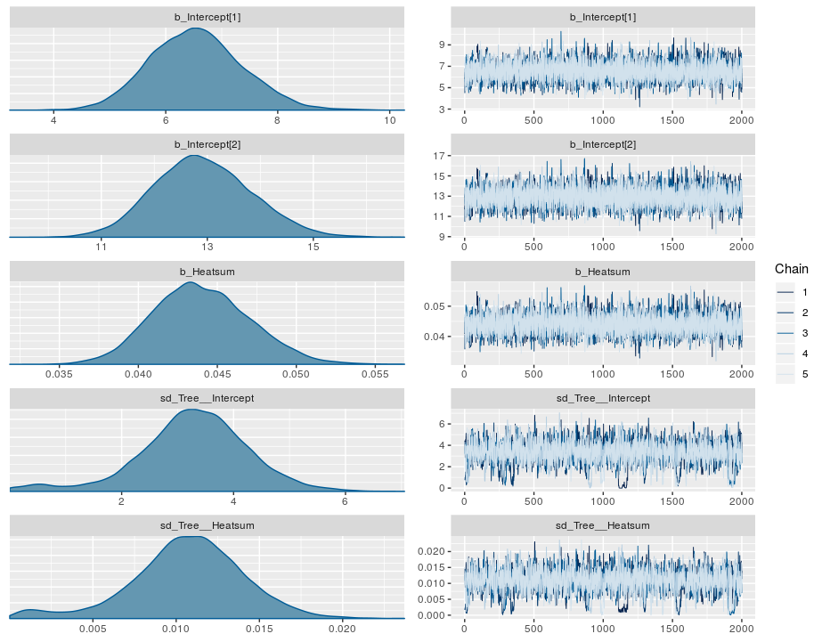

Image Caption: posterior distribution for Intercept1, Intercept2, Heatsum and Standard deviations

## Translate parameter values into day of year values